# 4 IVIVE and POD Comparisons

Katie Paul Friedman

2024-12-01

# 1 Load Data

## 1.1 Toxicodynamic NAM data

```r
#load('./source/tier1_NAMs_apcra_pro_03072022.RData')
#load('./source/tier1_NAMs_apcra_pro_02102023.RData')
#load('./source/in_vitro/tier1_NAMs_apcra_pro_04032023.RData')
load('./source/in_vitro/tier1_NAMs_apcra_pro_02262024.RData')
colnames(asnm.tier1) # this is the file for all BMDs/ACCs
```

```
##  [1] "dsstox_substance_id"      "chnm"
##  [3] "modl_acc_5p"              "ATG"
##  [5] "BSK"                      "NVS"
##  [7] "CCTE"                     "STM"
##  [9] "httr.u20s.pod.sig"        "httr.mcf7.pod.sig"
## [11] "httr.heparg.pod.sig"      "htpp.u2os.pac.min"
## [13] "Astar_BEAS2B_final"       "Astar_HepG2_final"
## [15] "Astar_HK2_final"          "min.acc.targeted.nam"
## [17] "col_min"                  "min.httr.htpp.targetnams"
```

```r
# mega.mc5.hitc1 may be useful if we want to apply armitage model when BSK data are updated
```

## 1.2 In vivo data for comparison

- ToxVal 9.4 PODs
- APCRA retrospective case study PODs

```r
load('./source/in_vivo/apcra_pro_toxval_v9_4_PODs.RData')
apcra.ret <- as.data.table(read.xlsx('./source/chem/Supp_File_2_pod_ratio_master_final.xlsx', sheet=1)) # for comparison
```

## 1.3 AQC information

```r
ad.tbl <- as.data.table(read.xlsx('./source/chem/apcra_chem_ad.xlsx', sheet='apcra_ad', colNames = TRUE))
```

## 1.4 Toxicokinetic data additions

- 137 chemicals have human HTTK data prior to loading in silico

```r
#asnm.tier1$CASRN <- apcra.list$CASRN[match(asnm.tier1$dsstox_substance_id, apcra.list$DTXSID)] # there were deformatted CASRN causing a bug

httk.chem.tbl <- as.data.table(chem.physical_and_invitro.data)
asnm.tier1$CASRN <- httk.chem.tbl$CAS[match(asnm.tier1$dsstox_substance_id, httk.chem.tbl$DTXSID)]

asnm.tier1.df <- as.data.frame(subset(asnm.tier1, CASRN %in% get_cheminfo(species=c('Human'))))
```

- Add the Health Canada data supplied by Marc Beal.
- With this contribution, we are at 154 substances that have bioactivity and HTTK.

```r
hc.httk <- as.data.table(read.xlsx('./source/httk/20191025-Health_Canada_Prospective_Data_HTTK.xlsx', sheet = 'add_chemtable', colNames = TRUE))

#hc.httk[is.na(Human.Funbound.plasma)] # true for DTXSID7023938 only

hc.httk[is.na(Human.Funbound.plasma), Human.Funbound.plasma := 0] # bug in HTTK is that it will not run 3 compss if is.na(Fup), so set to zero
hc.httk.df <- as.data.frame(hc.httk)

chem.physical_and_invitro.data <- add_chemtable(hc.httk.df,
                                                current.table=chem.physical_and_invitro.data,
                                                data.list=list(Compound="Compound",
                                                               CAS="CAS",
                                                               DTXSID="DTXSID",
                                                               Clint="Human.Clint",
                                                               #Clint.pValue="Human.Clint.pValue", # don't have it
                                                               Funbound.plasma="Human.Funbound.plasma",
                                                               #LogP="logP",
                                                               MW="MW",
                                                               Species="Species",
                                                               Reference="Human.Clint.Reference"
                                                               #pKa_Accept="pKa_Accept", # don't have this
                                                               #pKa_Donor="pKa_Donor" # don't have this
                                                ),
                                                overwrite=T)
```

```r
asnm.tier1.df <- as.data.frame(subset(asnm.tier1, CASRN %in% get_cheminfo(species=c('Human'), model="3compartmentss"))) #148
asnm.tier1.df.pbtk <- as.data.frame(subset(asnm.tier1, CASRN %in% get_cheminfo(species=c('Human'), model="pbtk"))) #131
```

```r
httk.chem.tbl <- as.data.table(chem.physical_and_invitro.data)
httk.chem.tbl.apcra <- httk.chem.tbl[DTXSID %in% asnm.tier1[,dsstox_substance_id]] #196 but could include rat/other species
httk.chem.tbl.apcra.hu <- as.data.frame(subset(httk.chem.tbl.apcra, CAS %in% get_cheminfo(species=c('Human'), model="3compartmentss"))) #148

httk.chem.tbl.apcra.hu.pbtk <- as.data.frame(subset(httk.chem.tbl.apcra, CAS %in% get_cheminfo(species=c('Human'), model="pbtk"))) #131

httk.chem.tbl.apcra.3css <- httk.chem.tbl.apcra[!is.na(Human.Clint)] #166

dtxsids <- setdiff(httk.chem.tbl.apcra.3css$DTXSID, httk.chem.tbl.apcra.hu$DTXSID)
write.csv(httk.chem.tbl.apcra[DTXSID %in% dtxsids], "./source/httk/test_get_cheminfo_Human_3compss.csv")

httk.chem.tbl.apcra.3css[DTXSID %in% dtxsids]
```

| Compound | CAS | CAS.Checksum | DTXSID | Formula | All.Compound.Names | logHenry | logHenry.Reference | logMA | logMA.Reference | logP | logP.Reference | logPwa | logPwa.Reference | logWSol | logWSol.Reference | MP | MP.Reference | MW | MW.Reference | pKa_Accept | pKa_Accept.Reference | pKa_Donor | pKa_Donor.Reference | All.Species | Chemical.Class | Dog.Foral | Dog.Foral.Reference | DTXSID.Reference | Formula.Reference | … |
| --- | --- | --- | --- | --- | --- | --- | --- | --- | --- | --- | --- | --- | --- | --- | --- | --- | --- | --- | --- | --- | --- | --- | --- | --- | --- | --- | --- | --- | --- | --- |
| Pyridaben | 96489-71-3 | TRUE | DTXSID5032573 | C19H25ClN2OS | Pyridaben\|Dtxsid5032573\|96489-71-3 | -4.34 | OPERAv2.9 | NA | NA | 6.37 | OPERAv2.9 | 3.95 | OPERAv2.9 | -7.35 | OPERAv2.9 | 111 | OPERAv2.9 | 364.9 | EPA | 4.57 | OPERAv2.9 | NA | NA | Human |  | NA | NA | EPA | EPA | … |
| Methyl laurate | 111-82-0 | TRUE | DTXSID5026889 | C13H26O2 | Methyl laurate\|Methyl dodecanoate\|Dtxsid5026889\|111-82-0 | -2.93 | OPERAv2.9 | NA | NA | 5.41 | OPERAv2.9 | 1.49 | OPERAv2.9 | -4.70 | OPERAv2.9 | 3 | OPERAv2.9 | 214.3 | EPA | NA | NA | NA | NA | Human |  | NA | NA | EPA | EPA | … |
| "3,3,4,4,5,5,6,6,7,7,8,8,8-tridecafluorooctyl methacrylate" | 2144-53-8 | TRUE | DTXSID3047558 | C12H9F13O2 | "3,3,4,4,5,5,6,6,7,7,8,8,8-tridecafluorooctyl methacrylate"\|Tridecafluorohexylethyl methacrylate\|3,3,4,4,5,5,6,6,7,7,8,8,8-tridecafluorooctyl methacrylate\|2-(perfluorohexyl)ethyl methacrylate\|Dtxs… | -3.15 | OPERAv2.9 | NA | NA | 5.20 | OPERAv2.9 | -0.64 | OPERAv2.9 | -6.54 | OPERAv2.9 | -37 | OPERAv2.9 | 432.2 | EPA | NA | NA | NA | NA | Human | PFAS | NA | NA | EPA | EPA | … |
| Potassium nonafluoro-1-butanesulfonate | 29420-49-3 | TRUE | DTXSID3037707 | C4F9KO3S | Potassium nonafluoro-1-butanesulfonate\|Pfbs-k\|Potassium perfluorobutanesulfonate\|Dtxsid3037707\|29420-49-3 | -3.92 | OPERAv2.9 | NA | NA | 0.26 | OPERAv2.9 | 3.90 | OPERAv2.9 | -2.14 | OPERAv2.9 | 188 | OPERAv2.9 | 338.2 | EPA | NA | NA | -1.61 | OPERAv2.9 | Human | PFAS | NA | NA | EPA | EPA | … |
| Aldrin | 309-00-2 | TRUE | DTXSID8020040 | C12H8Cl6 | Aldrin\|Dtxsid8020040\|309-00-2 | -3.88 | OPERAv2.9 | NA | NA | 6.50 | OPERAv2.9 | 2.16 | OPERAv2.9 | -7.14 | OPERAv2.9 | 241 | OPERAv2.9 | 364.9 | EPA | NA | NA | NA | NA | Human\|Rat |  | NA | NA | EPA | EPA | … |
| "2,6-dimethylaniline" | 87-62-7 | TRUE | DTXSID8026307 | C8H11N | "2,6-dimethylaniline"\|2,6-dimethylaniline\|Dtxsid8026307\|87-62-7 | -3.84 | OPERAv2.9 | NA | NA | 1.84 | OPERAv2.9 | 4.64 | OPERAv2.9 | -1.17 | OPERAv2.9 | 11 | OPERAv2.9 | 121.2 | EPA | 3.94 | OPERAv2.9 | NA | NA | Human |  | NA | NA | EPA | EPA | … |
| "1,2,4,5-tetrachlorobenzene" | 95-94-3 | TRUE | DTXSID7024320 | C6H2Cl4 | "1,2,4,5-tetrachlorobenzene"\|1,2,4,5-tetrachlorobenzene\|Dtxsid7024320\|95-94-3 | -3.00 | OPERAv2.9 | 4.27 | Endo 2011 | 4.62 | OPERAv2.9 | 1.01 | OPERAv2.9 | -5.01 | OPERAv2.9 | 138 | OPERAv2.9 | 215.9 | EPA | NA | NA | NA | NA | Human |  | NA | NA | EPA | EPA | … |
| Bis(4-hydroxyphenyl)methane | 620-92-8 | TRUE | DTXSID9022445 | C13H12O2 | Bis(4-hydroxyphenyl)methane\|Dtxsid9022445\|620-92-8 | -9.23 | OPERAv2.9 | NA | NA | 2.91 | OPERAv2.9 | 5.27 | OPERAv2.9 | -2.95 | OPERAv2.9 | 163 | OPERAv2.9 | 200.2 | EPA | NA | NA | 9.65 | OPERAv2.9 | Human |  | NA | NA | EPA | EPA | … |
| 2-phenylethyl phenylacetate | 102-20-5 | TRUE | DTXSID0044494 | C16H16O2 | 2-phenylethyl phenylacetate\|Dtxsid0044494\|102-20-5 | -6.00 | OPERAv2.9 | NA | NA | 3.80 | OPERAv2.9 | 4.38 | OPERAv2.9 | -4.12 | OPERAv2.9 | 17 | OPERAv2.9 | 240.3 | EPA | NA | NA | NA | NA | Human |  | NA | NA | EPA | EPA | … |
| N-butyldiethanolamine | 102-79-4 | TRUE | DTXSID1044354 | C8H19NO2 | N-butyldiethanolamine\|N-butyl diethanolamine\|Dtxsid1044354\|102-79-4 | -9.57 | OPERAv2.9 | NA | NA | 0.58 | OPERAv2.9 | 7.19 | OPERAv2.9 | 0.70 | OPERAv2.9 | -70 | OPERAv2.9 | 161.2 | EPA | 8.91 | OPERAv2.9 | NA | NA | Human |  | NA | NA | EPA | EPA | … |

[output cut: 8 more lines]

```r
get.cheminfo.human.3css <- as.data.frame(subset(httk.chem.tbl.apcra, CAS %in% get_cheminfo(species=c('Human'), model = "3compartmentss"))) #148

httk.chem.tbl.apcra[is.na(Human.Funbound.plasma), Human.Funbound.plasma := 0]
httk.chem.tbl.apcra[is.na(Human.Clint.pValue), Human.Clint.pValue := 0]
```

- Here are the substances that have “missing” HTTK.
- Note that we cover all with in silico (Sipes et al 2017) approaches if we want to.

```r
httk.have <- subset(asnm.tier1, CASRN %in% get_cheminfo(species=c('Human'), model='3compartmentss')) # following add of Health Canada data, 148
httk.missing <- asnm.tier1[!CASRN %in% httk.have[,CASRN]] #48 chemicals - may include a bunch of aqc failures

kable(httk.missing[,c('dsstox_substance_id','chnm')])
```

| dsstox_substance_id | chnm |
| --- | --- |
| DTXSID0023745 | D-Xylose |
| DTXSID0041270 | 3,5,5-Trimethylhexyl acetate |
| DTXSID0044494 | 2-Phenylethyl phenylacetate |
| DTXSID0044608 | Propylsilanetriyl triacetate |
| DTXSID0047113 | (-)-Ambroxide |
| DTXSID1027134 | Bis(2-ethylhexyl) phosphate |
| DTXSID1027891 | Calcium dodecylbenzene sulfonate |
| DTXSID1038822 | Neopentyl glycol dibenzoate |
| DTXSID1039719 | Nitric acid, calcium salt (2:1) |
| DTXSID1044352 | Methyl phenylacetate |
| DTXSID1044354 | N-Butyldiethanolamine |
| DTXSID1044934 | 4,5-Dihydroxy-1,3-dimethylimidazolidin-2-one |
| DTXSID1044938 | Ethenylsilanetriyl triacetate |
| DTXSID2029246 | Triethoxyoctylsilane |
| DTXSID2041200 | N,N′-Disalicylidene-1,2-diaminopropane |
| DTXSID2047725 | 2,2,2-Trichloro-1-phenylethyl acetate |
| DTXSID3027792 | Ethyltriacetoxysilane |
| DTXSID3037707 | Potassium perfluorobutanesulfonate |
| DTXSID3044463 | Ethenyl(triethoxy)silane |
| DTXSID3047558 | 2-(Perfluorohexyl)ethyl methacrylate |
| DTXSID4029692 | Potassium nitrate |
| DTXSID4044400 | Tetrabutylammonium bromide |
| DTXSID4044791 | Benzyl propanoate |
| DTXSID5026889 | Methyl dodecanoate |
| DTXSID5032573 | Pyridaben |
| DTXSID5040700 | Trimethoxyphenylsilane |
| DTXSID6020226 | Cadmium chloride |
| DTXSID6025301 | 2-Ethylhexyl glycidyl ether |
| DTXSID6042490 | Triethoxymethylsilane |
| DTXSID7020215 | Butylated hydroxyanisole |
| DTXSID7021607 | Hexanoic acid |
| DTXSID7024320 | 1,2,4,5-Tetrachlorobenzene |
| DTXSID7025219 | Sodium dodecylbenzenesulfonate |
| DTXSID7025502 | Linalool |
| DTXSID7027837 | Tripropylene glycol |
| DTXSID7044764 | 2-Phenylethyl 2-methylpropanoate |
| DTXSID7047198 | Ethyl 2-methylpentanoate |
| DTXSID8020040 | Aldrin |
| DTXSID8026307 | 2,6-Dimethylaniline |
| DTXSID8027036 | 2,2-Dimethylpropane-1,3-diol |
| DTXSID8044755 | Prop-2-en-1-yl 3-cyclohexylpropanoate |
| DTXSID8044961 | Bis{2-[2-(propan-2-yl)-1,3-oxazolidin-3-yl]ethyl} hexane-1,6-diylbiscarbamate |
| DTXSID9021639 | Nonanal |
| DTXSID9022445 | Bis(4-hydroxyphenyl)methane |
| DTXSID9040215 | Dimethyl (3-((hydroxymethyl)amino)-3-oxopropyl)phosphonate |
| DTXSID9042382 | Tetrapropyl orthosilicate |
| DTXSID9044374 | p-Methylacetophenone |
| DTXSID9047201 | 4-Formyl-2-methoxyphenyl isobutyrate |

- how many substances can follow pbtk model? 131

```r
pbtk.have <- subset(asnm.tier1, CASRN %in% get_cheminfo(species=c('Human'), model='pbtk')) #only 131 have this
```

# 2 Calculate AEDs

- Load in silico information to fill gaps

```r
load_sipes2017()
load_pradeep2020()
load_dawson2021()
```

- Make the ACC values into arithmetic micromolar units.

```r
col.num <- c("modl_acc_5p", "ATG", "BSK",
"NVS", "CCTE", "STM", "httr.u20s.pod.sig", "httr.mcf7.pod.sig", "httr.heparg.pod.sig", "htpp.u2os.pac.min", "Astar_BEAS2B_final",
"Astar_HepG2_final", "Astar_HK2_final", "min.acc.targeted.nam", "min.httr.htpp.targetnams")

asnm.tier1.arith <- asnm.tier1[, (col.num) := lapply(.SD, function(x) 10^(x)), .SDcols = col.num ]
```

- subsets for 3compss, pbtk

```r
#for (j in seq_along(names(asnm.tier1.arith))) {
#  set(asnm.tier1,
#      i = which(is.na(asnm.tier1.arith[[j]])),
#      j = j,
#      value = 1000)
#}


asnm.tier1.arith.3css <- subset(asnm.tier1.arith, CASRN %in% get_cheminfo(species=c('Human'), model='3compartmentss')) #168


asnm.tier1.arith.pbtk <- subset(asnm.tier1.arith, CASRN %in% get_cheminfo(species=c('Human'), model='pbtk')) #165

httk.dt <- as.data.table(chem.physical_and_invitro.data)
httk.dt <- httk.dt[DTXSID %in% apcra.list[,DTXSID]]
httk.dt[,c('Human.Clint','Human.Funbound.plasma')]
```

| Human.Clint | Human.Funbound.plasma |
| --- | --- |
| 136.5 | 0 |
| 0.7456 | 0.4809 |
| 32.39 | 0.04763 |
| 21.66 | 0.1971 |
| 0 | 0.02147 |
| 41.15 | 0.836 |
| 0,0,0,0.999 | 0 |
| 17.28 | 0.03201 |
| 18.47 | 0.0003605 |
| 24.41 | 0.175 |

[output cut: 190 more lines]

```r
asnm.tier1.arith.3css <- as.data.table(asnm.tier1.arith)
asnm.tier1.arith.pbtk <- as.data.table(asnm.tier1.arith)
```

```r
colnames(asnm.tier1.arith.3css)
```

```
##  [1] "dsstox_substance_id"      "chnm"
##  [3] "modl_acc_5p"              "ATG"
##  [5] "BSK"                      "NVS"
##  [7] "CCTE"                     "STM"
##  [9] "httr.u20s.pod.sig"        "httr.mcf7.pod.sig"
## [11] "httr.heparg.pod.sig"      "htpp.u2os.pac.min"
## [13] "Astar_BEAS2B_final"       "Astar_HepG2_final"
## [15] "Astar_HK2_final"          "min.acc.targeted.nam"
## [17] "col_min"                  "min.httr.htpp.targetnams"
## [19] "CASRN"
```

- 3 compss HTTK v2.3.0

```r
set.seed(1234567)

tictoc::tic() # start timer

aed50.3compss.5pacc <- mcmapply(mc.cores=1,
                              asnm.tier1.arith.3css$modl_acc_5p,
                              asnm.tier1.arith.3css$CASRN,
                              FUN=function(x,y){
                                calc_mc_oral_equiv(
                                  conc=x,
                                     chem.cas=y,
                                     which.quantile=c(0.50),
                                     species='Human',
                                     restrictive.clearance = T,
                                     output.units='mgpkgpday')

                              })

aed50.3compss.atg <- mcmapply(mc.cores=1,
                              asnm.tier1.arith.3css$ATG,
                              asnm.tier1.arith.3css$CASRN,
                              FUN=function(x,y){
                                calc_mc_oral_equiv(
                                  conc=x,
                                     chem.cas=y,
                                     which.quantile=c(0.50),
                                     species='Human',
                                     restrictive.clearance = T,
                                     output.units='mgpkgpday')

                              })

aed50.3compss.bsk <- mcmapply(mc.cores=1,
                              asnm.tier1.arith.3css$BSK,
                              asnm.tier1.arith.3css$CASRN,
                              FUN=function(x,y){
                                calc_mc_oral_equiv(
                                  conc=x,
                                     chem.cas=y,
                                     which.quantile=c(0.50),
                                     species='Human',
                                     restrictive.clearance = T,
                                     output.units='mgpkgpday')

                              })

aed50.3compss.nvs <- mcmapply(mc.cores=1,
                              asnm.tier1.arith.3css$NVS,
                              asnm.tier1.arith.3css$CASRN,
                              FUN=function(x,y){
                                calc_mc_oral_equiv(
                                  conc=x,
                                     chem.cas=y,
                                     which.quantile=c(0.50),
                                     species='Human',
                                     restrictive.clearance = T,
                                     output.units='mgpkgpday')

                              })

aed50.3compss.ccte <- mcmapply(mc.cores=1,
                              asnm.tier1.arith.3css$CCTE,
                              asnm.tier1.arith.3css$CASRN,
                              FUN=function(x,y){
                                calc_mc_oral_equiv(
                                  conc=x,
                                     chem.cas=y,
                                     which.quantile=c(0.50),
                                     species='Human',
                                     restrictive.clearance = T,
                                     output.units='mgpkgpday')

                              })

aed50.3compss.stm <- mcmapply(mc.cores=1,
                              asnm.tier1.arith.3css$STM,
                              asnm.tier1.arith.3css$CASRN,
                              FUN=function(x,y){
                                calc_mc_oral_equiv(
                                  conc=x,
                                     chem.cas=y,
                                     which.quantile=c(0.50),
                                     species='Human',
                                     restrictive.clearance = T,
                                     output.units='mgpkgpday')

                              })

aed50.3compss.httr.mcf7.sigbmd <- mcmapply(mc.cores=1,
                              asnm.tier1.arith.3css$httr.mcf7.pod.sig,
                              asnm.tier1.arith.3css$CASRN,
                              FUN=function(x,y){
                                calc_mc_oral_equiv(
                                  conc=x,
                                     chem.cas=y,
                                     which.quantile=c(0.50),
                                     species='Human',
                                     restrictive.clearance = T,
                                     output.units='mgpkgpday')

                              })

aed50.3compss.httr.u2os.sigbmd <- mcmapply(mc.cores=1,
                              asnm.tier1.arith.3css$httr.u20s.pod.sig,
                              asnm.tier1.arith.3css$CASRN,
                              FUN=function(x,y){
                                calc_mc_oral_equiv(
                                  conc=x,
                                     chem.cas=y,
                                     which.quantile=c(0.50),
                                     species='Human',
                                     restrictive.clearance = T,
                                     output.units='mgpkgpday')

                              })

aed50.3compss.httr.heparg.sigbmd <- mcmapply(mc.cores=1,
                              asnm.tier1.arith.3css$httr.heparg.pod.sig,
                              asnm.tier1.arith.3css$CASRN,
                              FUN=function(x,y){
                                calc_mc_oral_equiv(
                                  conc=x,
                                     chem.cas=y,
                                     which.quantile=c(0.50),
                                     species='Human',
                                     restrictive.clearance = T,
                                     output.units='mgpkgpday')

                              })

aed50.3compss.htpp.u2os <- mcmapply(mc.cores=1,
                              asnm.tier1.arith.3css$htpp.u2os.pac.min,
                              asnm.tier1.arith.3css$CASRN,
                              FUN=function(x,y){
                                calc_mc_oral_equiv(
                                  conc=x,
                                     chem.cas=y,
                                     which.quantile=c(0.50),
                                     species='Human',
                                     restrictive.clearance = T,
                                     output.units='mgpkgpday')

                              })

aed50.3compss.astar.beas2b <- mcmapply(mc.cores=1,
                              asnm.tier1.arith.3css$Astar_BEAS2B_final,
                              asnm.tier1.arith.3css$CASRN,
                              FUN=function(x,y){
                                calc_mc_oral_equiv(
                                  conc=x,
                                     chem.cas=y,
                                     which.quantile=c(0.50),
                                     species='Human',
                                     restrictive.clearance = T,
                                     output.units='mgpkgpday')

                              })

aed50.3compss.astar.hepg2 <- mcmapply(mc.cores=1,
                              asnm.tier1.arith.3css$Astar_HepG2_final,
                              asnm.tier1.arith.3css$CASRN,
                              FUN=function(x,y){
                                calc_mc_oral_equiv(
                                  conc=x,
                                     chem.cas=y,
                                     which.quantile=c(0.50),
                                     species='Human',
                                     restrictive.clearance = T,
                                     output.units='mgpkgpday')

                              })

aed50.3compss.astar.hek293 <- mcmapply(mc.cores=1,
                              asnm.tier1.arith.3css$Astar_HK2_final,
                              asnm.tier1.arith.3css$CASRN,
                              FUN=function(x,y){
                                calc_mc_oral_equiv(
                                  conc=x,
                                     chem.cas=y,
                                     which.quantile=c(0.50),
                                     species='Human',
                                     restrictive.clearance = T,
                                     output.units='mgpkgpday')

                              })

asnm.tier1.arith.3css$aed50.3compss.5pacc <- aed50.3compss.5pacc
asnm.tier1.arith.3css$aed50.3compss.atg <- aed50.3compss.atg
asnm.tier1.arith.3css$aed50.3compss.bsk <- aed50.3compss.bsk
asnm.tier1.arith.3css$aed50.3compss.ccte <- aed50.3compss.ccte
asnm.tier1.arith.3css$aed50.3compss.nvs <- aed50.3compss.nvs
asnm.tier1.arith.3css$aed50.3compss.stm <- aed50.3compss.stm
asnm.tier1.arith.3css$aed50.3compss.atg <- aed50.3compss.atg
asnm.tier1.arith.3css$aed50.3compss.httr.mcf7.sigbmd <- aed50.3compss.httr.mcf7.sigbmd
asnm.tier1.arith.3css$aed50.3compss.httr.u2os.sigbmd <- aed50.3compss.httr.u2os.sigbmd
asnm.tier1.arith.3css$aed50.3compss.httr.heparg.sigbmd  <- aed50.3compss.httr.heparg.sigbmd
asnm.tier1.arith.3css$aed50.3compss.htpp.u2os  <- aed50.3compss.htpp.u2os
asnm.tier1.arith.3css$aed50.3compss.astar.beas2b  <- aed50.3compss.astar.beas2b
asnm.tier1.arith.3css$aed50.3compss.astar.hepg2  <- aed50.3compss.astar.hepg2
asnm.tier1.arith.3css$aed50.3compss.astar.hek293  <- aed50.3compss.astar.hek293

save(asnm.tier1.arith.3css, file='./output/asnm_tier1_arith_3css_Feb2024.RData')

tictoc::toc() # end timer
```

- PBTK version v2.3.0

```r
set.seed(1234567)

aed50.pbtk.5pacc <- mcmapply(mc.cores=1,
                              asnm.tier1.arith.pbtk$modl_acc_5p,
                              asnm.tier1.arith.pbtk$CASRN,
                              FUN=function(x,y){
                                calc_mc_oral_equiv(
                                  conc=x,
                                     chem.cas=y,
                                   model='pbtk',
                                     which.quantile=c(0.50),
                                     species='Human',
                                     restrictive.clearance = T,
                                     output.units='mgpkgpday'
                                 )

                              })
aed50.pbtk.atg <- mcmapply(mc.cores=1,
                              asnm.tier1.arith.pbtk$ATG,
                              asnm.tier1.arith.pbtk$CASRN,
                              FUN=function(x,y){
                                calc_mc_oral_equiv(
                                  conc=x,
                                     chem.cas=y,
                                  model='pbtk',
                                     which.quantile=c(0.50),
                                     species='Human',
                                     restrictive.clearance = T,
                                     output.units='mgpkgpday')

                              })

aed50.pbtk.bsk <- mcmapply(mc.cores=1,
                              asnm.tier1.arith.pbtk$BSK,
                              asnm.tier1.arith.pbtk$CASRN,
                              FUN=function(x,y){
                                calc_mc_oral_equiv(
                                  conc=x,
                                     chem.cas=y,
                                  model='pbtk',
                                     which.quantile=c(0.50),
                                     species='Human',
                                     restrictive.clearance = T,
                                     output.units='mgpkgpday')

                              })

aed50.pbtk.nvs <- mcmapply(mc.cores=1,
                              asnm.tier1.arith.pbtk$NVS,
                              asnm.tier1.arith.pbtk$CASRN,
                              FUN=function(x,y){
                                calc_mc_oral_equiv(
                                  conc=x,
                                     chem.cas=y,
                                     which.quantile=c(0.50),
                                     species='Human',
                                     restrictive.clearance = T,
                                     output.units='mgpkgpday')

                              })

aed50.pbtk.ccte <- mcmapply(mc.cores=1,
                              asnm.tier1.arith.pbtk$CCTE,
                              asnm.tier1.arith.pbtk$CASRN,
                              FUN=function(x,y){
                                calc_mc_oral_equiv(
                                  conc=x,
                                     chem.cas=y,
                                     which.quantile=c(0.50),
                                     species='Human',
                                     restrictive.clearance = T,
                                     output.units='mgpkgpday')

                              })

aed50.pbtk.stm <- mcmapply(mc.cores=1,
                              asnm.tier1.arith.pbtk$STM,
                              asnm.tier1.arith.pbtk$CASRN,
                              FUN=function(x,y){
                                calc_mc_oral_equiv(
                                  conc=x,
                                     chem.cas=y,
                                     which.quantile=c(0.50),
                                     species='Human',
                                     restrictive.clearance = T,
                                     output.units='mgpkgpday')

                              })

aed50.pbtk.httr.mcf7.sigbmd <- mcmapply(mc.cores=1,
                              asnm.tier1.arith.pbtk$httr.mcf7.pod.sig,
                              asnm.tier1.arith.pbtk$CASRN,
                              FUN=function(x,y){
                                calc_mc_oral_equiv(
                                  conc=x,
                                     chem.cas=y,
                                     which.quantile=c(0.50),
                                     species='Human',
                                     restrictive.clearance = T,
                                     output.units='mgpkgpday')

                              })

aed50.pbtk.httr.u2os.sigbmd <- mcmapply(mc.cores=1,
                              asnm.tier1.arith.pbtk$httr.u20s.pod.sig,
                              asnm.tier1.arith.pbtk$CASRN,
                              FUN=function(x,y){
                                calc_mc_oral_equiv(
                                  conc=x,
                                     chem.cas=y,
                                     which.quantile=c(0.50),
                                     species='Human',
                                     restrictive.clearance = T,
                                     output.units='mgpkgpday')

                              })

aed50.pbtk.httr.heparg.sigbmd <- mcmapply(mc.cores=1,
                              asnm.tier1.arith.pbtk$httr.heparg.pod.sig,
                              asnm.tier1.arith.pbtk$CASRN,
                              FUN=function(x,y){
                                calc_mc_oral_equiv(
                                  conc=x,
                                     chem.cas=y,
                                     which.quantile=c(0.50),
                                     species='Human',
                                     restrictive.clearance = T,
                                     output.units='mgpkgpday')

                              })

aed50.pbtk.htpp.u2os <- mcmapply(mc.cores=1,
                              asnm.tier1.arith.pbtk$htpp.u2os.pac.min,
                              asnm.tier1.arith.pbtk$CASRN,
                              FUN=function(x,y){
                                calc_mc_oral_equiv(
                                  conc=x,
                                     chem.cas=y,
                                     which.quantile=c(0.50),
                                     species='Human',
                                     restrictive.clearance = T,
                                     output.units='mgpkgpday')

                              })

aed50.pbtk.astar.beas2b <- mcmapply(mc.cores=1,
                              asnm.tier1.arith.pbtk$Astar_BEAS2B_final,
                              asnm.tier1.arith.pbtk$CASRN,
                              FUN=function(x,y){
                                calc_mc_oral_equiv(
                                  conc=x,
                                     chem.cas=y,
                                     which.quantile=c(0.50),
                                     species='Human',
                                     restrictive.clearance = T,
                                     output.units='mgpkgpday')

                              })

aed50.pbtk.astar.hepg2 <- mcmapply(mc.cores=1,
                              asnm.tier1.arith.pbtk$Astar_HepG2_final,
                              asnm.tier1.arith.pbtk$CASRN,
                              FUN=function(x,y){
                                calc_mc_oral_equiv(
                                  conc=x,
                                     chem.cas=y,
                                     which.quantile=c(0.50),
                                     species='Human',
                                     restrictive.clearance = T,
                                     output.units='mgpkgpday')

                              })

aed50.pbtk.astar.hek293 <- mcmapply(mc.cores=1,
                              asnm.tier1.arith.pbtk$Astar_HK2_final,
                              asnm.tier1.arith.pbtk$CASRN,
                              FUN=function(x,y){
                                calc_mc_oral_equiv(
                                  conc=x,
                                     chem.cas=y,
                                     which.quantile=c(0.50),
                                     species='Human',
                                     restrictive.clearance = T,
                                     output.units='mgpkgpday')

                              })

asnm.tier1.arith.pbtk$aed50.pbtk.5pacc <- aed50.pbtk.5pacc
asnm.tier1.arith.pbtk$aed50.pbtk.atg <- aed50.pbtk.atg
asnm.tier1.arith.pbtk$aed50.pbtk.bsk <- aed50.pbtk.bsk
asnm.tier1.arith.pbtk$aed50.pbtk.ccte <- aed50.pbtk.ccte
asnm.tier1.arith.pbtk$aed50.pbtk.nvs <- aed50.pbtk.nvs
asnm.tier1.arith.pbtk$aed50.pbtk.stm <- aed50.pbtk.stm
asnm.tier1.arith.pbtk$aed50.pbtk.atg <- aed50.pbtk.atg
asnm.tier1.arith.pbtk$aed50.pbtk.httr.mcf7.sigbmd <- aed50.pbtk.httr.mcf7.sigbmd
asnm.tier1.arith.pbtk$aed50.pbtk.httr.u2os.sigbmd <- aed50.pbtk.httr.u2os.sigbmd
asnm.tier1.arith.pbtk$aed50.pbtk.httr.heparg.sigbmd  <- aed50.pbtk.httr.heparg.sigbmd
asnm.tier1.arith.pbtk$aed50.pbtk.htpp.u2os  <- aed50.pbtk.htpp.u2os
asnm.tier1.arith.pbtk$aed50.pbtk.astar.beas2b  <- aed50.pbtk.astar.beas2b
asnm.tier1.arith.pbtk$aed50.pbtk.astar.hepg2  <- aed50.pbtk.astar.hepg2
asnm.tier1.arith.pbtk$aed50.pbtk.astar.hek293  <- aed50.pbtk.astar.hek293

save(asnm.tier1.arith.pbtk, file='./output/asnm_tier1_arith_pbtk_2024.RData')
```

Load the AEDs generated as RData files.

```r
load(file='./output/asnm_tier1_arith_pbtk_2024.RData')
load(file='./output/asnm_tier1_arith_3css_Feb2024.RData')
```

```r
asnm.tier1.all <- merge.data.table(asnm.tier1.arith.3css,
                                   asnm.tier1.arith.pbtk[,c('dsstox_substance_id',"aed50.pbtk.5pacc",
"aed50.pbtk.atg", "aed50.pbtk.bsk", "aed50.pbtk.ccte", "aed50.pbtk.nvs",
"aed50.pbtk.stm", "aed50.pbtk.httr.mcf7.sigbmd", "aed50.pbtk.httr.u2os.sigbmd",
"aed50.pbtk.httr.heparg.sigbmd", "aed50.pbtk.htpp.u2os", "aed50.pbtk.astar.beas2b",
"aed50.pbtk.astar.hepg2", "aed50.pbtk.astar.hek293")],
by='dsstox_substance_id',
all.x=TRUE,
all.y=TRUE)

asnm.tier1.all <- asnm.tier1.all[,c("dsstox_substance_id",
                                   "aed50.3compss.5pacc",
"aed50.3compss.atg", "aed50.3compss.bsk", "aed50.3compss.ccte",
"aed50.3compss.nvs", "aed50.3compss.stm", "aed50.3compss.httr.mcf7.sigbmd",
"aed50.3compss.httr.u2os.sigbmd", "aed50.3compss.httr.heparg.sigbmd",
"aed50.3compss.htpp.u2os", "aed50.3compss.astar.beas2b", "aed50.3compss.astar.hepg2",
"aed50.3compss.astar.hek293", "aed50.pbtk.5pacc", "aed50.pbtk.atg",
"aed50.pbtk.bsk", "aed50.pbtk.ccte", "aed50.pbtk.nvs", "aed50.pbtk.stm",
"aed50.pbtk.httr.mcf7.sigbmd", "aed50.pbtk.httr.u2os.sigbmd",
"aed50.pbtk.httr.heparg.sigbmd", "aed50.pbtk.htpp.u2os", "aed50.pbtk.astar.beas2b",
"aed50.pbtk.astar.hepg2", "aed50.pbtk.astar.hek293")]
```

```r
# convert all Inf to NA
for (j in 1:ncol(asnm.tier1.all)) set(asnm.tier1.all, which(is.infinite(asnm.tier1.all[[j]])), j, NA)

# log10 all AED values
cols <- c( "aed50.3compss.5pacc", "aed50.3compss.atg",
"aed50.3compss.bsk", "aed50.3compss.ccte", "aed50.3compss.nvs",
"aed50.3compss.stm", "aed50.3compss.httr.mcf7.sigbmd", "aed50.3compss.httr.u2os.sigbmd",
"aed50.3compss.httr.heparg.sigbmd", "aed50.3compss.htpp.u2os",
"aed50.3compss.astar.beas2b", "aed50.3compss.astar.hepg2", "aed50.3compss.astar.hek293",
"aed50.pbtk.5pacc", "aed50.pbtk.atg", "aed50.pbtk.bsk", "aed50.pbtk.ccte",
"aed50.pbtk.nvs", "aed50.pbtk.stm", "aed50.pbtk.httr.mcf7.sigbmd",
"aed50.pbtk.httr.u2os.sigbmd", "aed50.pbtk.httr.heparg.sigbmd",
"aed50.pbtk.htpp.u2os", "aed50.pbtk.astar.beas2b", "aed50.pbtk.astar.hepg2",
"aed50.pbtk.astar.hek293")

asnm.tier1.logaed <- as.data.frame(asnm.tier1.all)
asnm.tier1.logaed[cols] <- lapply(asnm.tier1.logaed[cols], log10) # make the aed50s in log10-mg/kg/day
```

```r
# replace NA by the median for each row
asnm.tier1.pred <- as.data.frame(asnm.tier1.logaed)
asnm.tier1.pred[cols] <- t(apply(asnm.tier1.pred[cols], 1, function(x)
  replace(x, is.na(x), median(x, na.rm=TRUE))))

# add in the stuff to predict
asnm.tier1.pred <- merge.data.table(asnm.tier1.pred,
                                    toxval.apcra.summary[,c('dtxsid','p5.toxval.numeric')],
                                    by.x='dsstox_substance_id',
                                    by.y='dtxsid') %>% as.data.table()


asnm.tier1.pred[, log.p5.toxval.pod := p5.toxval.numeric] # this value was already logged, so just renaming in new column to match old code
```

# 3 Random Forest Prediction of In Vivo POD

The goal of this section was to understand if 3Css or pbtk better outperformed each other, or if addition of certain properties or features could create a baseline RF model that clearly outperformed taking simple means or medians. This work is meant to be exploratory for the purposes of deciding if it is worth pursuing a ML model for a dataset this small. In general, the finding is that the dataset is likely too small and too little of the variance explained by any of the descriptors (AEDs, physchem properties).

The results were less than compelling, but there are some learnings. + One is that 3Css vs. pbtk model made little overall difference in the prediction. + The Rsquared values tend to be less then 0.2 + The RMSE values tend to approach 1.2 + Addition of physchem properties like Fup and LogP suggests LogP would be an important feature, but fails to reduce the variance in prediction

## 3.1 Baseline model

```r
# fill NA (missing) values with median by technology type

for (j in seq_along(names(asnm.tier1.pred))) {
  set(asnm.tier1.pred,
      i = which(is.na(asnm.tier1.pred[[j]])),
      j = j,
      value = median(asnm.tier1.pred[[j]], na.rm = TRUE))
}
```

```r
colnames(asnm.tier1.pred)
```

```
##  [1] "dsstox_substance_id"              "aed50.3compss.5pacc"
##  [3] "aed50.3compss.atg"                "aed50.3compss.bsk"
##  [5] "aed50.3compss.ccte"               "aed50.3compss.nvs"
##  [7] "aed50.3compss.stm"                "aed50.3compss.httr.mcf7.sigbmd"
##  [9] "aed50.3compss.httr.u2os.sigbmd"   "aed50.3compss.httr.heparg.sigbmd"
## [11] "aed50.3compss.htpp.u2os"          "aed50.3compss.astar.beas2b"
## [13] "aed50.3compss.astar.hepg2"        "aed50.3compss.astar.hek293"
## [15] "aed50.pbtk.5pacc"                 "aed50.pbtk.atg"
## [17] "aed50.pbtk.bsk"                   "aed50.pbtk.ccte"
## [19] "aed50.pbtk.nvs"                   "aed50.pbtk.stm"
## [21] "aed50.pbtk.httr.mcf7.sigbmd"      "aed50.pbtk.httr.u2os.sigbmd"
## [23] "aed50.pbtk.httr.heparg.sigbmd"    "aed50.pbtk.htpp.u2os"
## [25] "aed50.pbtk.astar.beas2b"          "aed50.pbtk.astar.hepg2"
## [27] "aed50.pbtk.astar.hek293"          "p5.toxval.numeric"
## [29] "log.p5.toxval.pod"
```

```r
asnm.tier1.pred <- asnm.tier1.pred[!p5.toxval.numeric==0]
```

```r
control <- trainControl(method='repeatedcv',
                        number=5,
                        repeats=5)

metric <- "Accuracy"
set.seed(1234567)
mtry <- sqrt(26)
tunegrid <- expand.grid(.mtry=mtry)
rf_default <- train(data=asnm.tier1.pred[,c(3:27, 29)],
                    log.p5.toxval.pod~.,
                    method='rf',
                    metric='RMSE',
                    type='regression',
                    tunegrid=tunegrid,
                    trControl=control
                    )
print(rf_default)
```

```
## Random Forest
##
## 162 samples
##  25 predictor
##
## No pre-processing
## Resampling: Cross-Validated (5 fold, repeated 5 times)
## Summary of sample sizes: 129, 130, 129, 130, 130, 129, ...
## Resampling results across tuning parameters:
##
##   mtry  RMSE      Rsquared    MAE
##    2    477.1923  0.04181694  253.2660
##   13    492.1796  0.04152105  254.9761
##   25    497.4472  0.04236723  256.7507
##
## RMSE was used to select the optimal model using the smallest value.
## The final value used for the model was mtry = 2.
```

- Try just the 3css AEDs

```r
rf_3css <- train(data=asnm.tier1.pred[,c(3:14,29)],
                    log.p5.toxval.pod~.,
                    method='rf',
                    metric='RMSE',
                    tunegrid=tunegrid,
                    trControl=control
                    )
print(rf_3css)
```

```
## Random Forest
##
## 162 samples
##  12 predictor
##
## No pre-processing
## Resampling: Cross-Validated (5 fold, repeated 5 times)
## Summary of sample sizes: 130, 130, 128, 130, 130, 130, ...
## Resampling results across tuning parameters:
##
##   mtry  RMSE      Rsquared    MAE
##    2    498.0754  0.02249936  263.6867
##    7    513.0495  0.01913953  265.2638
##   12    523.5881  0.01250596  265.2759
##
## RMSE was used to select the optimal model using the smallest value.
## The final value used for the model was mtry = 2.
```

```r
rf_pbtk <- train(data=asnm.tier1.pred[,c(15:27,29)],
                    log.p5.toxval.pod~.,
                    method='rf',
                    metric='RMSE',
                    tunegrid=tunegrid,
                    trControl=control
                    )
print(rf_pbtk)
```

```
## Random Forest
##
## 162 samples
##  13 predictor
##
## No pre-processing
## Resampling: Cross-Validated (5 fold, repeated 5 times)
## Summary of sample sizes: 130, 129, 130, 130, 129, 129, ...
## Resampling results across tuning parameters:
##
##   mtry  RMSE      Rsquared    MAE
##    2    459.3065  0.06277761  241.7751
##    7    471.5925  0.05408160  246.3817
##   13    485.7473  0.03561677  248.6692
##
## RMSE was used to select the optimal model using the smallest value.
## The final value used for the model was mtry = 2.
```

## 3.2 Feature Importance and Applying RFE

- Desire to remove features with absolute correlation of 0.75 or higher.
- Model may perform better if highly correlated features are removed.
- 3css and pbtk are highly correlated for the same asnm; can’t include both.

```r
# load the data
data(asnm.tier1.pred)

# calculate the correlation matrix
correlationMatrix <- cor(asnm.tier1.pred[,3:27])
print(correlationMatrix)
```

```
##                                  aed50.3compss.atg aed50.3compss.bsk
## aed50.3compss.atg                        1.0000000         0.8110485
## aed50.3compss.bsk                        0.8110485         1.0000000
## aed50.3compss.ccte                       0.6070720         0.7096592
## aed50.3compss.nvs                        0.7579399         0.6933789
## aed50.3compss.stm                        0.8134241         0.8328426
## aed50.3compss.httr.mcf7.sigbmd           0.7644873         0.7526530
## aed50.3compss.httr.u2os.sigbmd           0.7816827         0.7770047
## aed50.3compss.httr.heparg.sigbmd         0.7979622         0.7655058
## aed50.3compss.htpp.u2os                  0.8413404         0.8715282
## aed50.3compss.astar.beas2b               0.6680660         0.7728207
## aed50.3compss.astar.hepg2                0.6949364         0.7940563
## aed50.3compss.astar.hek293               0.6837647         0.7825830
## aed50.pbtk.5pacc                         0.6634101         0.6777579
## aed50.pbtk.atg                           0.9946018         0.8080448
## aed50.pbtk.bsk                           0.8074999         0.9846661
## aed50.pbtk.ccte                          0.6064386         0.7092968
## aed50.pbtk.nvs                           0.7585033         0.6939922
## aed50.pbtk.stm                           0.8125890         0.8318233
## aed50.pbtk.httr.mcf7.sigbmd              0.7640505         0.7523964
## aed50.pbtk.httr.u2os.sigbmd              0.7804318         0.7772711
## aed50.pbtk.httr.heparg.sigbmd            0.7973437         0.7652424
## aed50.pbtk.htpp.u2os                     0.8415515         0.8714348
## aed50.pbtk.astar.beas2b                  0.6698425         0.7737555
## aed50.pbtk.astar.hepg2                   0.6953004         0.7941489
## aed50.pbtk.astar.hek293                  0.6837282         0.7822375
##                                  aed50.3compss.ccte aed50.3compss.nvs
## aed50.3compss.atg                         0.6070720         0.7579399
## aed50.3compss.bsk                         0.7096592         0.6933789
## aed50.3compss.ccte                        1.0000000         0.5203477
## aed50.3compss.nvs                         0.5203477         1.0000000
## aed50.3compss.stm                         0.6643672         0.6787865
## aed50.3compss.httr.mcf7.sigbmd            0.6782356         0.6199869
## aed50.3compss.httr.u2os.sigbmd            0.5829054         0.6492695
## aed50.3compss.httr.heparg.sigbmd          0.6008908         0.6491282
## aed50.3compss.htpp.u2os                   0.7473554         0.6597756
## aed50.3compss.astar.beas2b                0.6266571         0.6179107
## aed50.3compss.astar.hepg2                 0.6554261         0.6182998
## aed50.3compss.astar.hek293                0.6761913         0.6002780
## aed50.pbtk.5pacc                          0.6618822         0.6031232
```

[output cut: 387 more lines]

```
## aed50.3compss.astar.hepg2                     0.9999229               0.8663597
## aed50.3compss.astar.hek293                    0.8665451               0.9999406
## aed50.pbtk.5pacc                              0.6720828               0.6656278
## aed50.pbtk.atg                                0.6997186               0.6922182
## aed50.pbtk.bsk                                0.8030712               0.7973285
## aed50.pbtk.ccte                               0.6571869               0.6767741
## aed50.pbtk.nvs                                0.6201693               0.6013014
## aed50.pbtk.stm                                0.7952560               0.7590127
## aed50.pbtk.httr.mcf7.sigbmd                   0.6581767               0.6594440
## aed50.pbtk.httr.u2os.sigbmd                   0.7300421               0.7471415
## aed50.pbtk.httr.heparg.sigbmd                 0.6283755               0.6225679
## aed50.pbtk.htpp.u2os                          0.8155634               0.8085298
## aed50.pbtk.astar.beas2b                       0.8453185               0.8333611
## aed50.pbtk.astar.hepg2                        1.0000000               0.8666052
## aed50.pbtk.astar.hek293                       0.8666052               1.0000000
```

```r
# find attributes that are highly correlated
highlyCorrelated <- findCorrelation(correlationMatrix, cutoff=0.75)
print(highlyCorrelated)
```

```
##  [1] 22  9 15  2  5 18 14  1  7 20 24 11 25 12 23  8  6  3 17
```

- Consider ranking by feature importance.

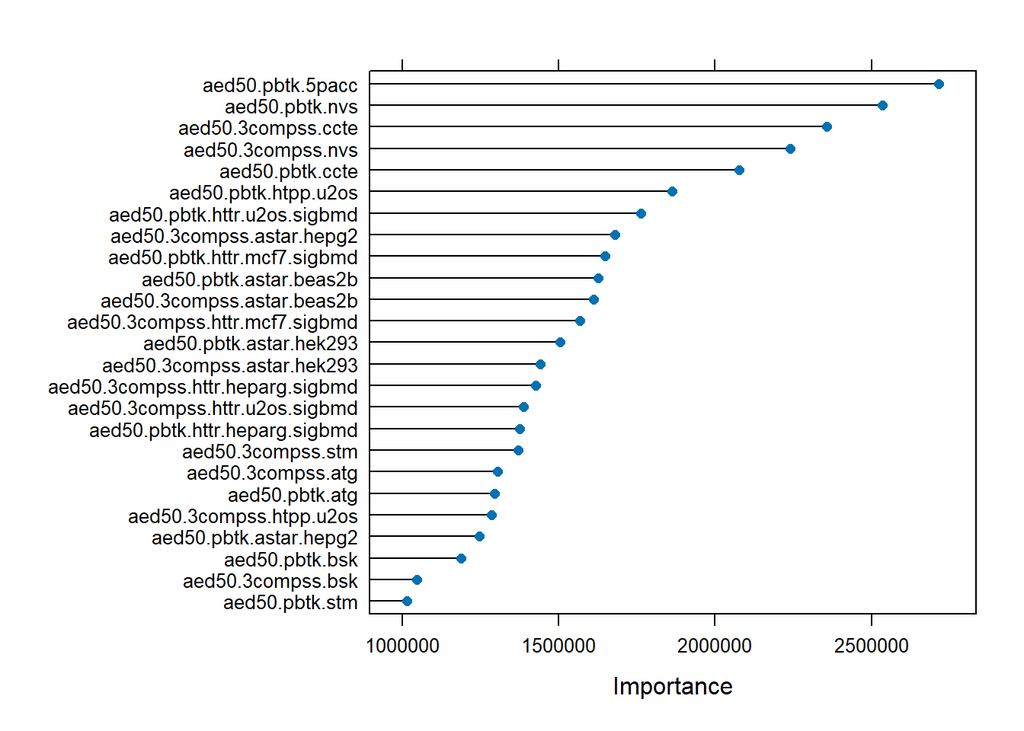

```r
model <- train(log.p5.toxval.pod~., data=asnm.tier1.pred[,c(3:27,29)], method='rf', trControl=control)
importance <- varImp(model, scale=FALSE)
plot(importance)
```

```r
print(importance)
```

```
## rf variable importance
##
##   only 20 most important variables shown (out of 25)
##
##                                  Overall
## aed50.pbtk.5pacc                 2716464
## aed50.pbtk.nvs                   2534298
## aed50.3compss.ccte               2358177
## aed50.3compss.nvs                2241490
## aed50.pbtk.ccte                  2077687
## aed50.pbtk.htpp.u2os             1863655
## aed50.pbtk.httr.u2os.sigbmd      1763729
## aed50.3compss.astar.hepg2        1680425
## aed50.pbtk.httr.mcf7.sigbmd      1647522
## aed50.pbtk.astar.beas2b          1626785
## aed50.3compss.astar.beas2b       1612931
## aed50.3compss.httr.mcf7.sigbmd   1568125
## aed50.pbtk.astar.hek293          1505012
## aed50.3compss.astar.hek293       1441337
## aed50.3compss.httr.heparg.sigbmd 1426060
## aed50.3compss.httr.u2os.sigbmd   1386949
## aed50.pbtk.httr.heparg.sigbmd    1374788
## aed50.3compss.stm                1371291
## aed50.3compss.atg                1304733
## aed50.pbtk.atg                   1295109
```

- try RFE

```r
control <- rfeControl(functions=rfFuncs, method='cv', number=5)
results <- rfe(asnm.tier1.pred[,c(3:14,16:27)], as.matrix(asnm.tier1.pred[,28]), sizes = c(1:25), rfeControl = control)
print(results)
```

```
##
## Recursive feature selection
##
## Outer resampling method: Cross-Validated (5 fold)
##
## Resampling performance over subset size:
##
##  Variables  RMSE Rsquared   MAE RMSESD RsquaredSD  MAESD Selected
##          1 671.5  0.01543 317.0  323.6    0.01523 128.76
##          2 531.8  0.01695 283.7  333.6    0.02142 114.31
##          3 531.6  0.04453 275.3  333.0    0.07277 107.41
##          4 511.4  0.04700 261.5  339.4    0.06228 105.05
##          5 494.0  0.04616 254.1  349.1    0.07990 107.59
##          6 497.1  0.03617 255.0  346.9    0.04895 114.15
##          7 489.7  0.04919 247.0  346.6    0.07584 109.19
##          8 491.1  0.02621 253.2  342.1    0.02711 101.51
##          9 491.7  0.04268 252.4  343.0    0.03931  98.52
##         10 484.5  0.04706 248.7  345.4    0.05291  99.70
##         11 485.7  0.04335 250.1  344.4    0.04219 101.47
##         12 489.2  0.04820 250.7  343.2    0.04214  96.94
##         13 481.6  0.05344 248.9  346.8    0.05466  99.11
##         14 482.8  0.05310 249.8  347.1    0.04748  97.06
##         15 489.5  0.05300 255.7  345.9    0.05547  97.07
##         16 489.4  0.04624 254.6  343.7    0.04597  96.04
##         17 478.6  0.05913 248.5  349.5    0.05491  98.61
##         18 484.7  0.05278 255.2  349.9    0.06395  99.30
##         19 479.7  0.05973 249.5  347.8    0.04931  96.99
##         20 481.0  0.06707 251.8  346.7    0.06514  97.20
##         21 477.4  0.06875 251.1  352.1    0.05014 102.91        *
##         22 484.0  0.06014 252.7  348.2    0.05345  99.43
##         23 479.6  0.06987 252.5  347.6    0.07430  95.64
##         24 484.5  0.06403 255.0  347.0    0.06233  98.58
##
## The top 5 variables (out of 21):
##    aed50.3compss.atg, aed50.3compss.astar.hepg2, aed50.pbtk.astar.hepg2, aed50.pbtk.atg, aed50.3compss.htpp.u2os
```

```r
predictors(results)
```

```
##  [1] "aed50.3compss.atg"              "aed50.3compss.astar.hepg2"
##  [3] "aed50.pbtk.astar.hepg2"         "aed50.pbtk.atg"
##  [5] "aed50.3compss.htpp.u2os"        "aed50.pbtk.nvs"
##  [7] "aed50.3compss.nvs"              "aed50.pbtk.htpp.u2os"
##  [9] "aed50.pbtk.httr.mcf7.sigbmd"    "aed50.3compss.httr.mcf7.sigbmd"
## [11] "aed50.3compss.ccte"             "aed50.pbtk.astar.hek293"
## [13] "aed50.pbtk.ccte"                "aed50.3compss.astar.hek293"
## [15] "aed50.pbtk.httr.u2os.sigbmd"    "aed50.pbtk.stm"
## [17] "aed50.3compss.httr.u2os.sigbmd" "aed50.pbtk.bsk"
## [19] "aed50.3compss.stm"              "aed50.3compss.astar.beas2b"
## [21] "aed50.pbtk.astar.beas2b"
```

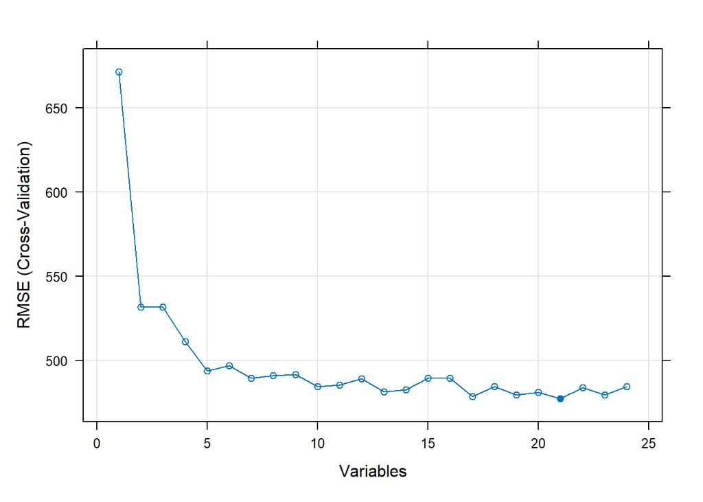

```r
plot(results, type = c("g","o"))
```

- Add additional features to better describe the chemicals: Fup, logP?

```r
asnm.tier1.pred$Fup <- httk.chem.tbl.apcra$Human.Funbound.plasma[match(asnm.tier1.pred$dsstox_substance_id,
                                                                       httk.chem.tbl.apcra$DTXSID)]

asnm.tier1.pred$logP <- httk.chem.tbl.apcra$logP[match(asnm.tier1.pred$dsstox_substance_id,
                                                                       httk.chem.tbl.apcra$DTXSID)]

asnm.tier1.pred$Fup[is.na(asnm.tier1.pred$Fup)] <- 0
asnm.tier1.pred[, Fup := tstrsplit(Fup,",", fixed=TRUE, keep=c(1))]
asnm.tier1.pred$logP[is.na(asnm.tier1.pred$logP)] <- 0


control <- rfeControl(functions=rfFuncs, method='cv', number=5)


results <- rfe(asnm.tier1.pred[,c(3:14,16:27,30:31)], as.matrix(asnm.tier1.pred[,29]), sizes = c(1:27), rfeControl = control)


print(results)
```

```
##
## Recursive feature selection
##
## Outer resampling method: Cross-Validated (5 fold)
##
## Resampling performance over subset size:
##
##  Variables  RMSE Rsquared   MAE RMSESD RsquaredSD MAESD Selected
##          1 652.8  0.07161 288.8  275.5    0.14947 92.03
##          2 520.6  0.09830 223.9  260.0    0.13098 46.48
##          3 495.0  0.09811 222.7  274.9    0.12015 56.74        *
##          4 501.6  0.06624 231.8  280.7    0.09483 62.24
##          5 508.8  0.05414 234.0  275.4    0.08980 57.58
##          6 521.4  0.04527 237.5  274.4    0.06815 64.15
##          7 497.3  0.06627 228.1  275.7    0.09245 58.53
```

[output cut: 22 more lines]

```r
predictors(results)
```

```
## [1] "aed50.3compss.atg" "logP"              "aed50.pbtk.atg"
```

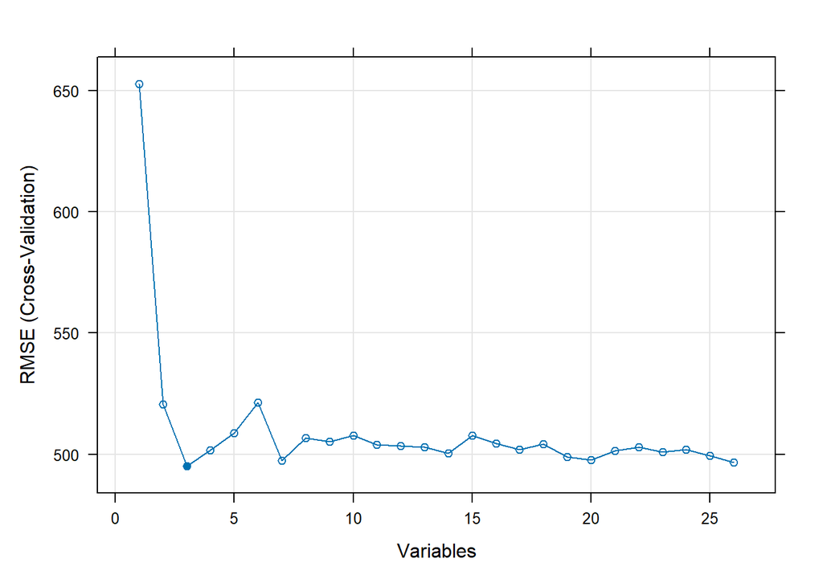

```r
plot(results, type = c("g","o"))
```

# 4 Create AED estimates

The approach taken is to come up with one AED per chemical x technology grouping. These AEDs are highly correlated with each other and so one value per grouping makes sense. Preference to pbtk when available (over 3css).

```r
asnm.tier1.all <- merge.data.table(asnm.tier1.arith.3css,
                                   asnm.tier1.arith.pbtk[,c('dsstox_substance_id',"aed50.pbtk.5pacc",
"aed50.pbtk.atg", "aed50.pbtk.bsk", "aed50.pbtk.ccte", "aed50.pbtk.nvs",
"aed50.pbtk.stm", "aed50.pbtk.httr.mcf7.sigbmd", "aed50.pbtk.httr.u2os.sigbmd",
"aed50.pbtk.httr.heparg.sigbmd", "aed50.pbtk.htpp.u2os", "aed50.pbtk.astar.beas2b",
"aed50.pbtk.astar.hepg2", "aed50.pbtk.astar.hek293")],
by='dsstox_substance_id',
all.x=TRUE,
all.y=TRUE)

asnm.tier1.all <- asnm.tier1.all[,c("dsstox_substance_id",
                                   "aed50.3compss.5pacc",
"aed50.3compss.atg", "aed50.3compss.bsk", "aed50.3compss.ccte",
"aed50.3compss.nvs", "aed50.3compss.stm", "aed50.3compss.httr.mcf7.sigbmd",
"aed50.3compss.httr.u2os.sigbmd", "aed50.3compss.httr.heparg.sigbmd",
"aed50.3compss.htpp.u2os", "aed50.3compss.astar.beas2b", "aed50.3compss.astar.hepg2",
"aed50.3compss.astar.hek293", "aed50.pbtk.5pacc", "aed50.pbtk.atg",
"aed50.pbtk.bsk", "aed50.pbtk.ccte", "aed50.pbtk.nvs", "aed50.pbtk.stm",
"aed50.pbtk.httr.mcf7.sigbmd", "aed50.pbtk.httr.u2os.sigbmd",
"aed50.pbtk.httr.heparg.sigbmd", "aed50.pbtk.htpp.u2os", "aed50.pbtk.astar.beas2b",
"aed50.pbtk.astar.hepg2", "aed50.pbtk.astar.hek293")]

# convert all Inf to NA
for (j in 1:ncol(asnm.tier1.all)) set(asnm.tier1.all, which(is.infinite(asnm.tier1.all[[j]])), j, NA)

cols <- c( "aed50.3compss.5pacc", "aed50.3compss.atg",
"aed50.3compss.bsk", "aed50.3compss.ccte", "aed50.3compss.nvs",
"aed50.3compss.stm", "aed50.3compss.httr.mcf7.sigbmd", "aed50.3compss.httr.u2os.sigbmd",
"aed50.3compss.httr.heparg.sigbmd", "aed50.3compss.htpp.u2os",
"aed50.3compss.astar.beas2b", "aed50.3compss.astar.hepg2", "aed50.3compss.astar.hek293",
"aed50.pbtk.5pacc", "aed50.pbtk.atg", "aed50.pbtk.bsk", "aed50.pbtk.ccte",
"aed50.pbtk.nvs", "aed50.pbtk.stm", "aed50.pbtk.httr.mcf7.sigbmd",
"aed50.pbtk.httr.u2os.sigbmd", "aed50.pbtk.httr.heparg.sigbmd",
"aed50.pbtk.htpp.u2os", "aed50.pbtk.astar.beas2b", "aed50.pbtk.astar.hepg2",
"aed50.pbtk.astar.hek293")

dup.dtxsid <- asnm.tier1.all[duplicated(asnm.tier1.all[,dsstox_substance_id]), dsstox_substance_id] # one substance had diff spids?

asnm.tier1.all <- as.data.frame(asnm.tier1.all)
asnm.tier1.all[cols] <- lapply(asnm.tier1.all[cols], log10) # make the aed50s in log10-mg/kg/day

asnm.tier1.all <- asnm.tier1.all %>%
  group_by(dsstox_substance_id) %>%
  summarise_if(is.numeric, min, na.rm=TRUE)
```

```r
asnm.tier1.all <- as.data.table(asnm.tier1.all)
# convert all Inf to NA
for (j in 1:ncol(asnm.tier1.all)) set(asnm.tier1.all, which(is.infinite(asnm.tier1.all[[j]])), j, NA)
```

- There’s a few chemicals we just can’t run

```r
dtxsids.aeds <- unique(asnm.tier1.all[,dsstox_substance_id])

apcra.list[!DTXSID %in% dtxsids.aeds]
```

| DTXSID | CASRN | preferred_name | stm.sc | stm.mc | stm.any | mea.acute | mea.acute.sc | mea.acute.any | httr.any | htpp.u2os |
| --- | --- | --- | --- | --- | --- | --- | --- | --- | --- | --- |
| DTXSID2024666 | 110-63-4 | 1,4-Butanediol | 1 | 0 | 1 | 1 | NA | 1 | 1 | 1 |
| DTXSID6041424 | 13254-34-7 | 2,6-Dimethyl-2-heptanol | 1 | 0 | 1 | 1 | NA | 1 | 1 | 1 |
| DTXSID7042011 | 97-78-9 | N-Dodecanoyl-N-methylglycine | 1 | 0 | 1 | 1 | NA | 1 | 0 | NA |
| DTXSID9044532 | 130-20-1 | D&C Blue No. 9 | 1 | 1 | 1 | 1 | NA | 1 | 0 | NA |
| DTXSID10895020 | 101193-62-8 | Quinotolast sodium | 0 | 0 | 0 | 0 | NA | 0 | 0 | NA |

## 4.1 Determine substances for which steady state is a poor assumption

```r
for (this.chem in asnm.tier1.all$dsstox_substance_id)
{
  skip_to_next <- FALSE
  tryCatch(
  out <- calc_css(dtxsid = this.chem,
         species= 'Human',
            output.units = 'uM',
            daily.dose=1,
            doses.per.day=1,
            tissue = 'plasma',
            model = 'pbtk',
         f=0.001,
         adjusted.Funbound.plasma = TRUE,
            restrictive.clearance = TRUE,
            well.stirred.correction =TRUE),
  error = function(e) {skip_to_next <<-TRUE})
  if(skip_to_next){next}
  index <- asnm.tier1.all$dsstox_substance_id==this.chem
  asnm.tier1.all[index, "the.day"] <- out["the.day"]
}
```

```r
asnm.tier1.all[the.day>90]
```

| dsstox_substance_id | aed50.3compss.5pacc | aed50.3compss.atg | aed50.3compss.bsk | aed50.3compss.ccte | aed50.3compss.nvs | aed50.3compss.stm | aed50.3compss.httr.mcf7.sigbmd | aed50.3compss.httr.u2os.sigbmd | aed50.3compss.httr.heparg.sigbmd | aed50.3compss.htpp.u2os | aed50.3compss.astar.beas2b | aed50.3compss.astar.hepg2 | aed50.3compss.astar.hek293 | aed50.pbtk.5pacc | aed50.pbtk.atg | aed50.pbtk.bsk | aed50.pbtk.ccte | aed50.pbtk.nvs | aed50.pbtk.stm | aed50.pbtk.httr.mcf7.sigbmd | aed50.pbtk.httr.u2os.sigbmd | aed50.pbtk.httr.heparg.sigbmd | aed50.pbtk.htpp.u2os | aed50.pbtk.astar.beas2b | aed50.pbtk.astar.hepg2 | aed50.pbtk.astar.hek293 | the.day |
| --- | --- | --- | --- | --- | --- | --- | --- | --- | --- | --- | --- | --- | --- | --- | --- | --- | --- | --- | --- | --- | --- | --- | --- | --- | --- | --- | --- |
| DTXSID0044818 | -2.3194832 | -1.985479 | -1.0523213 | -3.6352614 | NA | NA | NA | 0.34044411 | 0.36116100 | NA | -0.21724081 | NA | NA | -2.1603963 | -1.834756 | -0.8955129 | -3.685290 | NA | NA | NA | 0.36586222 | 0.35525991 | NA | -0.2435160 | NA | NA | 651 |
| DTXSID0047113 | -0.6447401 | -1.667360 | -1.7886124 | NA | NA | NA | NA | -1.30120375 | 0.94041686 | NA | 0.38489080 | NA | NA | -0.4981195 | -1.526951 | -1.6269040 | NA | NA | NA | NA | -1.31722335 | 0.94615739 | NA | 0.3740147 | NA | NA | 238 |
| DTXSID0048505 | -3.3198459 | -2.993106 | -2.4127382 | NA | -6.4634416 | -2.1195294 | -2.0306773 | -2.76674999 | -2.18802306 | -3.62378815 | NA | NA | NA | -3.1013845 | -2.793714 | -2.1928710 | NA | -6.4424928 | -2.1661520 | -2.0588365 | -2.74763249 | -2.19097928 | -3.61475132 | NA | NA | NA | 114 |
| DTXSID1020560 | -1.7883456 | -2.137213 | -0.9037854 | -3.6432095 | -1.9161392 | -0.4433357 | -0.3537924 | -0.97633608 | -0.75104638 | -2.60136568 | 0.29907126 | 0.1044871 | 0.4543875 | -1.7108572 | -2.073915 | -0.8116341 | -3.628009 | -1.9023957 | -0.4387793 | -0.3434227 | -0.99139983 | -0.74304185 | -2.59687948 | 0.2871296 | 0.09201847 | 0.4514794 | 276 |
| DTXSID1021956 | -1.9003194 | -2.018997 | -1.7304871 | NA | NA | NA | 0.2907022 | -1.71579493 | 0.28057837 | -1.58720357 | NA | -0.4534573 | NA | -3.0691528 | -3.182964 | -2.8863908 | NA | NA | NA | 0.2667020 | -1.71624662 | 0.26997968 | -1.57283860 | NA | -0.43132902 | NA | 5901 |
| DTXSID2020686 | -2.3649186 | -2.003051 | NA | -2.2944784 | -2.3453422 | NA | -0.9251836 | -1.42654818 | -1.37028467 | -1.76802097 | NA | -0.1233204 | NA | -2.1739252 | -1.812479 | NA | -2.288024 | -2.3627105 | NA | -0.9292235 | -1.41816408 | -1.38626386 | -1.77780395 | NA | -0.10204319 | NA | 290 |
| DTXSID3026697 | -1.0639389 | NA | NA | NA | -0.2812493 | NA | 1.4707044 | -0.96217525 | 1.48187241 | NA | -0.08729979 | NA | NA | -1.0664621 | NA | NA | NA | -0.2819968 | NA | 1.4769765 | -0.92885471 | 1.47523522 | NA | -0.0943660 | NA | NA | 408 |
| DTXSID4020375 | -0.5589336 | -1.312917 | -0.3665315 | -0.6560009 | -1.8224635 | NA | 0.6820548 | -0.04788592 | 0.67951874 | 0.01994668 | NA | 1.0004341 | 0.9997393 | -0.6777807 | -1.420788 | -0.4871822 | -0.617983 | -1.8230410 | NA | 0.7044937 | -0.07618628 | 0.69381485 | 0.02857125 | NA | 1.00086772 | 1.0064660 | 156 |
| DTXSID4032459 | -2.5536182 | -1.852942 | NA | NA | -2.8651856 | NA | 0.4168069 | -1.78436244 | 0.44653717 | NA | -0.07800157 | NA | NA | -2.3528127 | -1.632831 | NA | NA | -2.9058784 | NA | 0.4138025 | -1.80382381 | 0.44607094 | NA | -0.0911934 | NA | NA | 300 |
| DTXSID4034609 | -1.9779843 | -1.966979 | -1.4544455 | -2.5578339 | -2.3897658 | -0.7572102 | -0.9284862 | -1.17470374 | -0.56066731 | -1.33376290 | NA | NA | NA | -1.7999707 | -1.794796 | -1.2499547 | -2.553308 | -2.3962063 | -0.7552282 | -0.9150664 | -1.20964445 | -0.57511836 | -1.33970384 | NA | NA | NA | 205 |

[output cut: 7 more lines]

## 4.2 Create the ifelse to take the correct AED50

```r
asnm.tier1.all <- as.data.table(asnm.tier1.all)
asnm.tier1.all[ , aed50.atg := ifelse(!is.na(aed50.pbtk.atg), aed50.pbtk.atg, aed50.3compss.atg)]
asnm.tier1.all[ , aed50.bsk := ifelse(!is.na(aed50.pbtk.bsk), aed50.pbtk.bsk, aed50.3compss.bsk)]
asnm.tier1.all[ , aed50.ccte := ifelse(!is.na(aed50.pbtk.ccte), aed50.pbtk.ccte, aed50.3compss.ccte)]
asnm.tier1.all[ , aed50.nvs := ifelse(!is.na(aed50.pbtk.nvs), aed50.pbtk.nvs, aed50.3compss.nvs)]
asnm.tier1.all[ , aed50.stm := ifelse(!is.na(aed50.pbtk.stm), aed50.pbtk.stm, aed50.3compss.stm)]
asnm.tier1.all[ , aed50.httr.mcf7 := ifelse(!is.na(aed50.pbtk.httr.mcf7.sigbmd), aed50.pbtk.httr.mcf7.sigbmd, aed50.3compss.httr.mcf7.sigbmd)]
asnm.tier1.all[ , aed50.httr.u2os := ifelse(!is.na(aed50.pbtk.httr.u2os.sigbmd), aed50.pbtk.httr.u2os.sigbmd, aed50.3compss.httr.u2os.sigbmd)]
asnm.tier1.all[ , aed50.httr.heparg := ifelse(!is.na(aed50.pbtk.httr.heparg.sigbmd), aed50.pbtk.httr.heparg.sigbmd, aed50.3compss.httr.heparg.sigbmd)]
asnm.tier1.all[ , aed50.htpp.u2os := ifelse(!is.na(aed50.pbtk.htpp.u2os), aed50.pbtk.htpp.u2os, aed50.3compss.htpp.u2os)]
asnm.tier1.all[ , aed50.astar.beas2b := ifelse(!is.na(aed50.pbtk.astar.beas2b), aed50.pbtk.astar.beas2b, aed50.3compss.astar.beas2b)]
asnm.tier1.all[ , aed50.astar.hepg2 := ifelse(!is.na(aed50.pbtk.astar.hepg2), aed50.pbtk.astar.hepg2, aed50.3compss.astar.hepg2)]
asnm.tier1.all[ , aed50.astar.hek293 := ifelse(!is.na(aed50.pbtk.astar.hek293), aed50.pbtk.astar.hek293, aed50.3compss.astar.hek293)]
colnames(asnm.tier1.all)
```

```
##  [1] "dsstox_substance_id"              "aed50.3compss.5pacc"
##  [3] "aed50.3compss.atg"                "aed50.3compss.bsk"
##  [5] "aed50.3compss.ccte"               "aed50.3compss.nvs"
##  [7] "aed50.3compss.stm"                "aed50.3compss.httr.mcf7.sigbmd"
##  [9] "aed50.3compss.httr.u2os.sigbmd"   "aed50.3compss.httr.heparg.sigbmd"
## [11] "aed50.3compss.htpp.u2os"          "aed50.3compss.astar.beas2b"
## [13] "aed50.3compss.astar.hepg2"        "aed50.3compss.astar.hek293"
## [15] "aed50.pbtk.5pacc"                 "aed50.pbtk.atg"
## [17] "aed50.pbtk.bsk"                   "aed50.pbtk.ccte"
## [19] "aed50.pbtk.nvs"                   "aed50.pbtk.stm"
## [21] "aed50.pbtk.httr.mcf7.sigbmd"      "aed50.pbtk.httr.u2os.sigbmd"
## [23] "aed50.pbtk.httr.heparg.sigbmd"    "aed50.pbtk.htpp.u2os"
## [25] "aed50.pbtk.astar.beas2b"          "aed50.pbtk.astar.hepg2"
## [27] "aed50.pbtk.astar.hek293"          "the.day"
## [29] "aed50.atg"                        "aed50.bsk"
## [31] "aed50.ccte"                       "aed50.nvs"
## [33] "aed50.stm"                        "aed50.httr.mcf7"
## [35] "aed50.httr.u2os"                  "aed50.httr.heparg"
## [37] "aed50.htpp.u2os"                  "aed50.astar.beas2b"
## [39] "aed50.astar.hepg2"                "aed50.astar.hek293"
```

## 4.3 Add in ToxVal Summary values

I calculated different %-iles of ToxVal and we want to add them here. First we clean up the %-iles of ToxVal data.

```r
# Ensure columns are numeric and also log10 transform the quantiles that were calculated
col.num <- c("apcra.ret.5p.POD", "p5.toxval.numeric","p10.toxval.numeric","p15.toxval.numeric","p20.toxval.numeric",    "p25.toxval.numeric","p30.toxval.numeric")
toxval.apcra.summary <- toxval.apcra.summary[, (col.num) := lapply(.SD, function(x) log10(x)), .SDcols = col.num ]

# Do the same procedure with the subchronic-only data
col.num <- c("p5.toxval.numeric.sub","p10.toxval.numeric.sub","p15.toxval.numeric.sub","p20.toxval.numeric.sub","p25.toxval.numeric.sub","p30.toxval.numeric.sub")
toxval.apcra.summary.subchronic <- toxval.apcra.summary.subchronic[, (col.num) := lapply(.SD, function(x) log10(x)), .SDcols = col.num ]
```

Here we merge the %-iles of ToxVal data with the AED values in a datatable called asnm.tier1.all.

```r
asnm.tier1.all <- merge.data.table(asnm.tier1.all,
                                    toxval.apcra.summary[,c("dtxsid",
                                                            "p5.toxval.numeric",
                                                            "p10.toxval.numeric",
                                                            "p15.toxval.numeric",
                                                            "p20.toxval.numeric",
                                                            "p25.toxval.numeric",
                                                            "p30.toxval.numeric"
                                                          )],
                                    by.x='dsstox_substance_id',
                                    by.y='dtxsid',
                                   all.x = TRUE)

asnm.tier1.all <- merge.data.table(asnm.tier1.all,
                                    toxval.apcra.summary.subchronic[,c("dtxsid",
                                                            "p5.toxval.numeric.sub",
                                                            "p10.toxval.numeric.sub",
                                                            "p15.toxval.numeric.sub",
                                                            "p20.toxval.numeric.sub",
                                                            "p25.toxval.numeric.sub",
                                                            "p30.toxval.numeric.sub"
                                                          )],
                                    by.x='dsstox_substance_id',
                                    by.y='dtxsid',
                                   all.x = TRUE)

asnm.tier1.all <- merge.data.table(asnm.tier1.all,
                                   ad.tbl,
                                   by.x='dsstox_substance_id',
                                   by.y='DTXSID',
                                   all.x=TRUE)
colnames(asnm.tier1.all)
```

```
##  [1] "dsstox_substance_id"
##  [2] "aed50.3compss.5pacc"
##  [3] "aed50.3compss.atg"
##  [4] "aed50.3compss.bsk"
##  [5] "aed50.3compss.ccte"
##  [6] "aed50.3compss.nvs"
##  [7] "aed50.3compss.stm"
##  [8] "aed50.3compss.httr.mcf7.sigbmd"
##  [9] "aed50.3compss.httr.u2os.sigbmd"
## [10] "aed50.3compss.httr.heparg.sigbmd"
## [11] "aed50.3compss.htpp.u2os"
## [12] "aed50.3compss.astar.beas2b"
## [13] "aed50.3compss.astar.hepg2"
## [14] "aed50.3compss.astar.hek293"
## [15] "aed50.pbtk.5pacc"
```

[output cut: 52 more lines]

# 5 Evaluating AEDs

## 5.1 Baseline random forest model

```r
#dput(colnames(asnm.tier1.all))
# infer the median for the chemical for any missing (NA) data by giving median by row (median by chemical)
cols <- c("aed50.atg",
"aed50.bsk", "aed50.ccte", "aed50.nvs", "aed50.stm", "aed50.httr.mcf7",
"aed50.httr.u2os", "aed50.httr.heparg", "aed50.htpp.u2os", "aed50.astar.beas2b",
"aed50.astar.hepg2", "aed50.astar.hek293")

asnm.tier1.all3 <- as.data.frame(asnm.tier1.all)

# replace NA by the median for each row
asnm.tier1.all3[cols] <- t(apply(asnm.tier1.all3[cols], 1, function(x)
  replace(x, is.na(x), median(x, na.rm=TRUE))))

asnm.tier1.pred3 <- as.data.table(asnm.tier1.all3)

asnm.tier1.pred3 <- asnm.tier1.pred3[!is.na(p5.toxval.numeric)]
asnm.tier1.pred3 <- asnm.tier1.pred3[!is.na(aed50.3compss.5pacc)]
```

## 5.2 Random Forest in Caret for Prediction

```r
colnames(asnm.tier1.pred3)
```

```
##  [1] "dsstox_substance_id"
##  [2] "aed50.3compss.5pacc"
##  [3] "aed50.3compss.atg"
##  [4] "aed50.3compss.bsk"
##  [5] "aed50.3compss.ccte"
##  [6] "aed50.3compss.nvs"
##  [7] "aed50.3compss.stm"
##  [8] "aed50.3compss.httr.mcf7.sigbmd"
##  [9] "aed50.3compss.httr.u2os.sigbmd"
## [10] "aed50.3compss.httr.heparg.sigbmd"
## [11] "aed50.3compss.htpp.u2os"
## [12] "aed50.3compss.astar.beas2b"
## [13] "aed50.3compss.astar.hepg2"
## [14] "aed50.3compss.astar.hek293"
## [15] "aed50.pbtk.5pacc"
```

[output cut: 52 more lines]

There are 156 chemicals where we can actually compare to in vivo data from ToxVal in a “baseline” RF model for the AEDs by source.

### 5.2.1 Using ToxVal POD 5th%-ile

```r
set.seed(1234567)

control <- trainControl(method='repeatedcv',
                        number=10,
                        repeats=3)

metric <- "Accuracy"

mtry <- sqrt(12)
tunegrid <- expand.grid(.mtry=mtry)

rf_aedtriage5 <- train(data=asnm.tier1.pred3[,c(29:41)],
                    p5.toxval.numeric~.,
                    method='rf',
                    metric='RMSE',
                    tunegrid=tunegrid,
                    trControl=control
                    )
print(rf_aedtriage5)
```

```
## Random Forest
##
## 156 samples
##  12 predictor
##
## No pre-processing
## Resampling: Cross-Validated (10 fold, repeated 3 times)
## Summary of sample sizes: 140, 140, 140, 140, 140, 141, ...
## Resampling results across tuning parameters:
##
##   mtry  RMSE      Rsquared   MAE
##    2    1.272646  0.1717328  1.003412
##    7    1.288400  0.1631240  1.024890
##   12    1.306421  0.1482800  1.040599
##
## RMSE was used to select the optimal model using the smallest value.
## The final value used for the model was mtry = 2.
```

### 5.2.2 Using ToxVal POD 10th%-ile

```r
control <- trainControl(method='repeatedcv',
                        number=10,
                        repeats=3)

metric <- "Accuracy"

mtry <- sqrt(12)
tunegrid <- expand.grid(.mtry=mtry)

rf_aedtriage10 <- train(data=asnm.tier1.pred3[,c(29:40, 42)],
                    p10.toxval.numeric~.,
                    method='rf',
                    metric='RMSE',
                    tunegrid=tunegrid,
                    trControl=control
                    )
print(rf_aedtriage10)
```

```
## Random Forest
##
## 156 samples
##  12 predictor
##
## No pre-processing
## Resampling: Cross-Validated (10 fold, repeated 3 times)
## Summary of sample sizes: 140, 141, 140, 141, 140, 142, ...
## Resampling results across tuning parameters:
##
##   mtry  RMSE      Rsquared   MAE
##    2    1.201455  0.2117792  0.9277528
##    7    1.203070  0.2107874  0.9400488
##   12    1.217970  0.2009968  0.9579131
##
## RMSE was used to select the optimal model using the smallest value.
## The final value used for the model was mtry = 2.
```

### 5.2.3 Using ToxVal POD 15th%-ile

```r
control <- trainControl(method='repeatedcv',
                        number=10,
                        repeats=3)

metric <- "Accuracy"

mtry <- sqrt(12)
tunegrid <- expand.grid(.mtry=mtry)

rf_aedtriage15 <- train(data=asnm.tier1.pred3[,c(29:40, 43)],
                    p15.toxval.numeric~.,
                    method='rf',
                    metric='RMSE',
                    tunegrid=tunegrid,
                    trControl=control
                    )
print(rf_aedtriage15)
```

```
## Random Forest
##
## 156 samples
##  12 predictor
##
## No pre-processing
## Resampling: Cross-Validated (10 fold, repeated 3 times)
## Summary of sample sizes: 141, 142, 140, 140, 141, 140, ...
## Resampling results across tuning parameters:
##
##   mtry  RMSE      Rsquared   MAE
##    2    1.134057  0.1980437  0.8716302
##    7    1.136175  0.1958200  0.8865722
##   12    1.150766  0.1872208  0.9023615
##
## RMSE was used to select the optimal model using the smallest value.
## The final value used for the model was mtry = 2.
```

### 5.2.4 Using ToxVal POD 20th%-ile

```r
control <- trainControl(method='repeatedcv',
                        number=10,
                        repeats=3)

metric <- "Accuracy"

mtry <- sqrt(12)
tunegrid <- expand.grid(.mtry=mtry)

rf_aedtriage20 <- train(data=asnm.tier1.pred3[,c(29:40, 44)],
                    p20.toxval.numeric~.,
                    method='rf',
                    metric='RMSE',
                    tunegrid=tunegrid,
                    trControl=control
                    )
print(rf_aedtriage20)
```

```
## Random Forest
##
## 156 samples
##  12 predictor
##
## No pre-processing
## Resampling: Cross-Validated (10 fold, repeated 3 times)
## Summary of sample sizes: 141, 141, 141, 140, 140, 140, ...
## Resampling results across tuning parameters:
##
##   mtry  RMSE      Rsquared   MAE
##    2    1.078489  0.2185371  0.8414456
##    7    1.080252  0.2238107  0.8499251
##   12    1.090791  0.2197815  0.8619982
##
## RMSE was used to select the optimal model using the smallest value.
## The final value used for the model was mtry = 2.
```

### 5.2.5 Using ToxVal POD 25th%-ile

```r
control <- trainControl(method='repeatedcv',
                        number=10,
                        repeats=3,
                        savePredictions = TRUE)

metric <- "Accuracy"

mtry <- sqrt(12)
tunegrid <- expand.grid(.mtry=mtry)

rf_aedtriage25 <- train(data=asnm.tier1.pred3[,c(29:40, 45)],
                    p25.toxval.numeric~.,
                    method='rf',
                    metric='RMSE',
                    tunegrid=tunegrid,
                    trControl=control
                    )
print(rf_aedtriage25)
```

```
## Random Forest
##
## 156 samples
##  12 predictor
##
## No pre-processing
## Resampling: Cross-Validated (10 fold, repeated 3 times)
## Summary of sample sizes: 140, 140, 140, 141, 141, 140, ...
## Resampling results across tuning parameters:
##
##   mtry  RMSE      Rsquared   MAE
##    2    1.034176  0.1908275  0.8110035
##    7    1.031182  0.2058020  0.8123263
##   12    1.040796  0.1957915  0.8191603
##
## RMSE was used to select the optimal model using the smallest value.
## The final value used for the model was mtry = 7.
```

### 5.2.6 Using ToxVal POD 30th%-ile

```r
control <- trainControl(method='repeatedcv',
                        number=10,
                        repeats=3)

metric <- "Accuracy"

mtry <- sqrt(12)
tunegrid <- expand.grid(.mtry=mtry)

rf_aedtriage30 <- train(data=asnm.tier1.pred3[,c(29:40, 46)],
                    p30.toxval.numeric~.,
                    method='rf',
                    metric='RMSE',
                    tunegrid=tunegrid,
                    trControl=control
                    )
print(rf_aedtriage30)
```

```
## Random Forest
##
## 156 samples
##  12 predictor
##
## No pre-processing
## Resampling: Cross-Validated (10 fold, repeated 3 times)
## Summary of sample sizes: 140, 141, 140, 140, 141, 141, ...
## Resampling results across tuning parameters:
##
##   mtry  RMSE      Rsquared   MAE
##    2    1.006012  0.1992500  0.7884103
##    7    1.018400  0.1909281  0.7995112
##   12    1.027799  0.1877559  0.8075045
##
## RMSE was used to select the optimal model using the smallest value.
## The final value used for the model was mtry = 2.
```

## 5.3 Compare the minimum AED50 to ToxVal POD

- defining the minimum AED50 without CCTE-MEA does a little better on the whole

```r
#Calculate minimum of the minimum AED50 by source
asnm.tier1.pred3[,min.aed50 := min(aed50.atg,
aed50.bsk, aed50.nvs, aed50.stm, aed50.httr.mcf7,
aed50.httr.u2os, aed50.httr.heparg, aed50.htpp.u2os, aed50.astar.beas2b,
aed50.astar.hepg2, aed50.astar.hek293, na.rm=TRUE), by=c('dsstox_substance_id')]

asnm.tier1.pred3[,min.aed50 := as.numeric(min.aed50)]
```

```r
# min AED vs toxval 5th %ile
aed.toxval5 <- lm(p5.toxval.numeric ~ min.aed50,
            data= asnm.tier1.pred3)
summary(aed.toxval5)
```

```
##
## Call:
## lm(formula = p5.toxval.numeric ~ min.aed50, data = asnm.tier1.pred3)
##
## Residuals:
##     Min      1Q  Median      3Q     Max
## -4.3403 -0.7690  0.0395  0.8760  3.1980
##
## Coefficients:
##             Estimate Std. Error t value Pr(>|t|)
## (Intercept)  1.13086    0.11408   9.913  < 2e-16 ***
## min.aed50    0.36708    0.07075   5.188  6.6e-07 ***
## ---
## Signif. codes:  0 '***' 0.001 '**' 0.01 '*' 0.05 '.' 0.1 ' ' 1
##
## Residual standard error: 1.272 on 154 degrees of freedom
## Multiple R-squared:  0.1488, Adjusted R-squared:  0.1433
## F-statistic: 26.92 on 1 and 154 DF,  p-value: 6.604e-07
```

```r
#aed.toxval5.rmse <- round(sqrt(mean(aed.toxval5$residuals^2)),3)
#aed.toxval5.r2 <- round(summary(aed.toxval5)$r.squared,3)

# min AED vs toxval 10th %ile
aed.toxval10 <- lm(p10.toxval.numeric ~ min.aed50,
            data= asnm.tier1.pred3)
summary(aed.toxval10)
```

```
##
## Call:
## lm(formula = p10.toxval.numeric ~ min.aed50, data = asnm.tier1.pred3)
##
## Residuals:
##     Min      1Q  Median      3Q     Max
## -4.5237 -0.6795  0.0642  0.9075  3.0162
##
## Coefficients:
##             Estimate Std. Error t value Pr(>|t|)
## (Intercept)  1.28797    0.10842  11.879  < 2e-16 ***
## min.aed50    0.35132    0.06725   5.224  5.6e-07 ***
## ---
## Signif. codes:  0 '***' 0.001 '**' 0.01 '*' 0.05 '.' 0.1 ' ' 1
##
## Residual standard error: 1.209 on 154 degrees of freedom
## Multiple R-squared:  0.1505, Adjusted R-squared:  0.145
## F-statistic: 27.29 on 1 and 154 DF,  p-value: 5.599e-07
```

```r
# min AED vs toxval 15th %ile
aed.toxval15 <- lm(p15.toxval.numeric ~ min.aed50,
            data= asnm.tier1.pred3)
summary(aed.toxval15)
```

```
##
## Call:
## lm(formula = p15.toxval.numeric ~ min.aed50, data = asnm.tier1.pred3)
##
## Residuals:
##     Min      1Q  Median      3Q     Max
## -4.7048 -0.7134  0.0617  0.8143  2.8366
##
## Coefficients:
##             Estimate Std. Error t value Pr(>|t|)
## (Intercept)  1.44541    0.10275  14.067  < 2e-16 ***
## min.aed50    0.33722    0.06373   5.291 4.11e-07 ***
## ---
## Signif. codes:  0 '***' 0.001 '**' 0.01 '*' 0.05 '.' 0.1 ' ' 1
##
## Residual standard error: 1.146 on 154 degrees of freedom
## Multiple R-squared:  0.1538, Adjusted R-squared:  0.1483
## F-statistic:    28 on 1 and 154 DF,  p-value: 4.106e-07
```

```r
# min AED vs toxval 20th %ile
aed.toxval20 <- lm(p20.toxval.numeric ~ min.aed50,
            data= asnm.tier1.pred3)
summary(aed.toxval20)
```

```
##
## Call:
## lm(formula = p20.toxval.numeric ~ min.aed50, data = asnm.tier1.pred3)
##
## Residuals:
##     Min      1Q  Median      3Q     Max
## -4.3315 -0.6393  0.0711  0.7370  2.6884
##
## Coefficients:
##             Estimate Std. Error t value Pr(>|t|)
## (Intercept)  1.57232    0.09851  15.962  < 2e-16 ***
## min.aed50    0.32367    0.06110   5.298 3.99e-07 ***
## ---
## Signif. codes:  0 '***' 0.001 '**' 0.01 '*' 0.05 '.' 0.1 ' ' 1
##
## Residual standard error: 1.098 on 154 degrees of freedom
## Multiple R-squared:  0.1542, Adjusted R-squared:  0.1487
## F-statistic: 28.07 on 1 and 154 DF,  p-value: 3.988e-07
```

```r
# min AED vs toxval 25th %ile
aed.toxval25 <- lm(p25.toxval.numeric ~ min.aed50,
            data= asnm.tier1.pred3)
summary(aed.toxval25)
```

```
##
## Call:
## lm(formula = p25.toxval.numeric ~ min.aed50, data = asnm.tier1.pred3)
##
## Residuals:
##     Min      1Q  Median      3Q     Max
## -3.5614 -0.6293  0.0205  0.7055  2.5427
##
## Coefficients:
##             Estimate Std. Error t value Pr(>|t|)
## (Intercept)  1.68416    0.09381  17.953  < 2e-16 ***
## min.aed50    0.30208    0.05818   5.192  6.5e-07 ***
## ---
## Signif. codes:  0 '***' 0.001 '**' 0.01 '*' 0.05 '.' 0.1 ' ' 1
##
## Residual standard error: 1.046 on 154 degrees of freedom
## Multiple R-squared:  0.149,  Adjusted R-squared:  0.1434
## F-statistic: 26.95 on 1 and 154 DF,  p-value: 6.495e-07
```

```r
# min AED vs toxval 30th %ile
aed.toxval30 <- lm(p30.toxval.numeric ~ min.aed50,
            data= asnm.tier1.pred3)
summary(aed.toxval30)
```

```
##
## Call:
## lm(formula = p30.toxval.numeric ~ min.aed50, data = asnm.tier1.pred3)
##
## Residuals:
##     Min      1Q  Median      3Q     Max
## -3.6090 -0.6305  0.0312  0.7019  2.4460
##
## Coefficients:
##             Estimate Std. Error t value Pr(>|t|)
## (Intercept)  1.76954    0.09009  19.643  < 2e-16 ***
## min.aed50    0.29486    0.05587   5.277 4.39e-07 ***
## ---
## Signif. codes:  0 '***' 0.001 '**' 0.01 '*' 0.05 '.' 0.1 ' ' 1
##
## Residual standard error: 1.005 on 154 degrees of freedom
## Multiple R-squared:  0.1531, Adjusted R-squared:  0.1476
## F-statistic: 27.85 on 1 and 154 DF,  p-value: 4.386e-07
```

## 5.4 Median AED50 vs ToxVal PODs

Calculate the median AED50

```r
# Calculate median
asnm.tier1.pred3[,med.aed50 := median(aed50.atg,
aed50.bsk, aed50.nvs, aed50.stm, aed50.httr.mcf7,
aed50.httr.u2os, aed50.httr.heparg, aed50.htpp.u2os, aed50.astar.beas2b,
aed50.astar.hepg2, aed50.astar.hek293, na.rm=TRUE), by=c('dsstox_substance_id')]
```

Compute model for different ToxVal PODs First show med AED50 v 5th %ile POD

```r
# med AED vs toxval 5th %ile
aedmed.toxval5 <- lm(p5.toxval.numeric ~ med.aed50,
            data= asnm.tier1.pred3)
summary(aedmed.toxval5)
```

```
##
## Call:
## lm(formula = p5.toxval.numeric ~ med.aed50, data = asnm.tier1.pred3)
##
## Residuals:
##     Min      1Q  Median      3Q     Max
## -4.0872 -0.7997  0.0871  0.9382  3.4563
##
## Coefficients:
##             Estimate Std. Error t value Pr(>|t|)
## (Intercept)  0.79353    0.10404   7.628 2.31e-12 ***
## med.aed50    0.31673    0.06614   4.789 3.90e-06 ***
## ---
## Signif. codes:  0 '***' 0.001 '**' 0.01 '*' 0.05 '.' 0.1 ' ' 1
##
## Residual standard error: 1.286 on 154 degrees of freedom
## Multiple R-squared:  0.1296, Adjusted R-squared:  0.124
## F-statistic: 22.94 on 1 and 154 DF,  p-value: 3.904e-06
```

```r
# med AED vs toxval 10th %ile
aedmed.toxval10 <- lm(p10.toxval.numeric ~ med.aed50,
            data= asnm.tier1.pred3)
#summary(aedmed.toxval10)

# med AED vs toxval 15th %ile
aedmed.toxval15 <- lm(p15.toxval.numeric ~ med.aed50,
            data= asnm.tier1.pred3)
#summary(aedmed.toxval15)

# med AED vs toxval 20th %ile
aedmed.toxval20 <- lm(p20.toxval.numeric ~ med.aed50,
            data= asnm.tier1.pred3)
#summary(aedmed.toxval20)
```

```r
# med AED vs toxval 25th %ile
aedmed.toxval25 <- lm(p25.toxval.numeric ~ med.aed50,
            data= asnm.tier1.pred3)
summary(aedmed.toxval25)
```

```
##
## Call:
## lm(formula = p25.toxval.numeric ~ med.aed50, data = asnm.tier1.pred3)
##
## Residuals:
##     Min      1Q  Median      3Q     Max
## -3.2832 -0.6374  0.0873  0.7418  2.8004
##
## Coefficients:
##             Estimate Std. Error t value Pr(>|t|)
## (Intercept)  1.40096    0.08425  16.628  < 2e-16 ***
## med.aed50    0.28580    0.05356   5.336 3.34e-07 ***
## ---
## Signif. codes:  0 '***' 0.001 '**' 0.01 '*' 0.05 '.' 0.1 ' ' 1
##
## Residual standard error: 1.042 on 154 degrees of freedom
## Multiple R-squared:  0.156,  Adjusted R-squared:  0.1506
## F-statistic: 28.47 on 1 and 154 DF,  p-value: 3.341e-07
```

```r
# med AED vs toxval 30th %ile
aedmed.toxval30 <- lm(p30.toxval.numeric ~ med.aed50,
            data= asnm.tier1.pred3)
summary(aedmed.toxval30)
```

```
##
## Call:
## lm(formula = p30.toxval.numeric ~ med.aed50, data = asnm.tier1.pred3)
##
## Residuals:
##     Min      1Q  Median      3Q     Max
## -3.3375 -0.6881  0.0812  0.7709  2.6973
##
## Coefficients:
##             Estimate Std. Error t value Pr(>|t|)
## (Intercept)  1.49312    0.08090  18.455  < 2e-16 ***
## med.aed50    0.27889    0.05143   5.423 2.23e-07 ***
## ---
## Signif. codes:  0 '***' 0.001 '**' 0.01 '*' 0.05 '.' 0.1 ' ' 1
##
## Residual standard error: 1 on 154 degrees of freedom
## Multiple R-squared:  0.1603, Adjusted R-squared:  0.1549
## F-statistic:  29.4 on 1 and 154 DF,  p-value: 2.229e-07
```